# Take-Home Midterm Exam Fall 2019 Po-Chun Chen N11957611

## Problem 1

A student is using an unreliable RNA-seq experimental protocol for a particular experimental study. The probability that the protocol fails, and the experiment does not provide useable data, is 0.6. The probability that the protocol succeeds and provides useable data is 0.4. The student has 2 successful experiments so far and needs 3 successful experiments to proceed with statistical analysis of the data. The number of failures before a successful experiment is a random variable, X.

1. Identify the probability mass function for random variable X and its parameters, and write its equation.

$$f(x) = {{x+r-1}\choose{r-1}}(p)^r(1-p)^X$$

Where r is 1 in this case and p is 0.4, then we get

$$f(x) = {{x+1-1}\choose{1-1}}(0.4)^1(0.6)^X = (0.4)(0.6)^X$$

2. What is the median number of failures before a success (i.e., the 0.5 quantile for the probability mass function)? Use the approriate R function to compute this.

A: The answer is 1. The cumulative probability should at least larger than 0.5 for median. Therefore, it is 1 in this case.

```r
sum(dnbinom(c(0:1),1,0.4))
```

```
## [1] 0.64
```

```r
qnbinom(0.5,1,0.4)
```

```
## [1] 1
```

```r
qgeom(0.5,0.4)
```

```
## [1] 1
```

3. Use R to compute the probability of less than or equal to 2 failures before success and provide your R code.

A: Simply call the function pnbinom or pgeom to get the probability.

```r
pnbinom(2,1,0.4)
```

```
## [1] 0.784
```

```r
pgeom(2,0.4)
```

```
## [1] 0.784
```

## Problem 2

Red-green color blindness is a recessive allele caried on the X chromosom. Consider 3 generations of family members with the following complete phenotyic information but incomplete genotypic information. The color blindness genotype of the grandmother (GM) is known to be $\rm GM\,=\,X^+X^-$, where $\rm X^+$ denotes an X chromosome that carries the color blindness allele, and $\rm X^-$ denotes an X chrmosome that is normal. Thus, the grandmother is a carrier of the color blindness allele. The Granfather (GF) is not colorblind, so we can infer that $\rm GF\,=\,X^-Y$. A daughter of the grandmother and grandfather, and mother of 2 boys, is not color blind, but we do not know her genotype. If we do not look at the phenotypes of her 2 sons, all we can say is that the mother either carries the trait ($\rm M=X^+X^-$) with probability 0.5; or she is not a carrier ($\rm M=X^-X^-$ ) with probability 0.5.

If we know that neither of the 2 sons is color blind, we can infer their genotypes: they both have a normal X chromosome; i.e., $\rm S_1=X^-Y$ and $\rm S_2=X^-Y$. This genotypic information on the 2 sons changes the probability that the mother is a carrier.

Use Bayes rule to update the probability that the mother is a carrier by computing
$$\begin{equation}
\Pr\big\{\rm M=X^+X^-\,|\,\left(S_1=X^-Y\,\cap\,S_2=X^-Y\right)\big\}
\end{equation}$$

$$\begin{equation}\begin{split}
\Pr\big\{\rm M=X^+X^-\,|\,\left(S_1=X^-Y\,\cap\,S_2=X^-Y\right)\big\} &= \frac{\Pr\big\{\rm M=X^+X^-\,\cap\left(S_1=X^-Y\,\cap\,S_2=X^-Y\right)}{Pr\left(S_1=X^-Y\,\cap\,S_2=X^-Y\right)} \\&= \frac{(1/2)^3}{(1/4+1)*1/2} \\& = 1/5 = 0.2
\end{split}\end{equation}$$

## Problem 3

The study results from taking blood glucose levels in mmol/l from independent groups of normal and diseased mice is given in the file ``midterm_mice.RData’’ (in variables “diseased” and “normal”).

Plot and compare the data using a: (i) box-plot (ii) stripchart (iii) stacked histograms. Explain the elements of a box plot, and describe the advantages of each type of plot.

A: For the elements in a box plot, the line at the top and the bottom is the maximum and minimum. The line in the middle of box is median. As for the two lines in the bottom of box and the top of box is 25th percentile and 75th percentile.

For box plot, the box plot can show a variable’s location and spread. Sometimes it also show outlier. As for the limitation, box plot do not show the details of the distribution as well as the values.

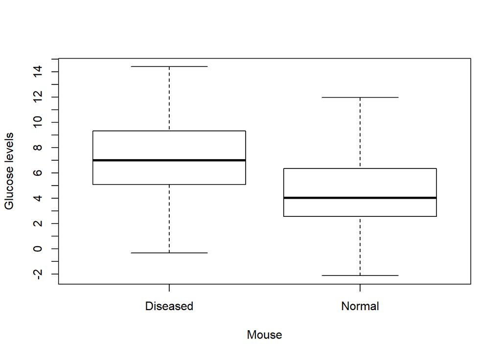

```r
load("C:/Users/PoChun/Desktop/Master_NYU/Statistics in Biology/Midterm/midterm_upload_2019/midterm_mice.RData")
mice_diseased <- diseased
mice_normal <- normal
boxplot(mice_diseased, mice_normal,names = c("Diseased","Normal"),ylab = "Glucose levels",xlab = "Mouse",yaxt="n")
axis(2,-5:20)
```

For strip plot, it is a kind of dot plot. They are useful for highlighting clusters and gaps, as well as outliers like box plot. As for the limitations, often you need to count to get the frequency which is time-consuming.Also, it is hard to construct by hand with large amount of data.

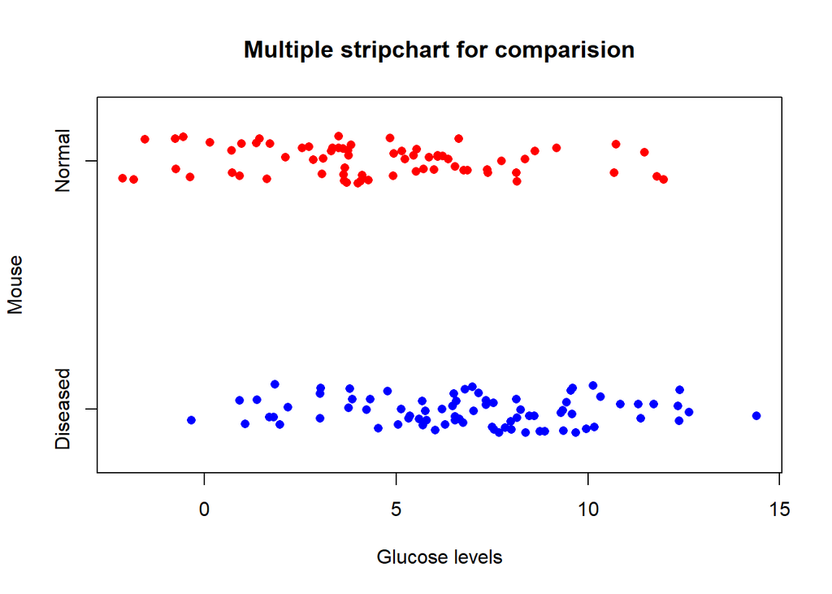

```r
stripchart_combine<- list("Diseased"=mice_diseased, "Normal"=mice_normal)
stripchart(stripchart_combine,
main="Multiple stripchart for comparision",
xlab="Glucose levels",
ylab="Mouse",
method="jitter",
col=c("Blue","red"),
pch=16
)
```

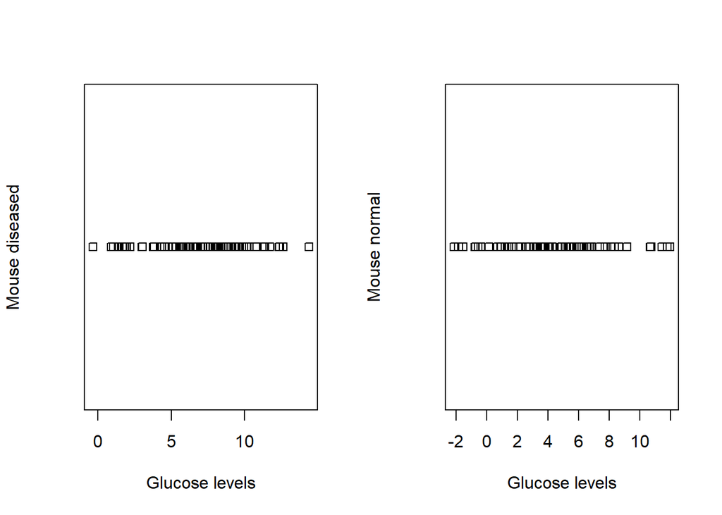

```r
par(mfrow=c(1,2))
stripchart(mice_diseased, xlab = "Glucose levels", ylab = "Mouse diseased")
stripchart(mice_normal, xlab = "Glucose levels", ylab = "Mouse normal")
```

For stacked histograms, the stacked histograms show how a larger category is divided into smaller subcategories (Like the distribution of glucose level in this case) and what the relationship of each part has on the total amount. As for the limitation, it is harder to read if the bar has more segments(two in our case).

```r
library(devtools)
```

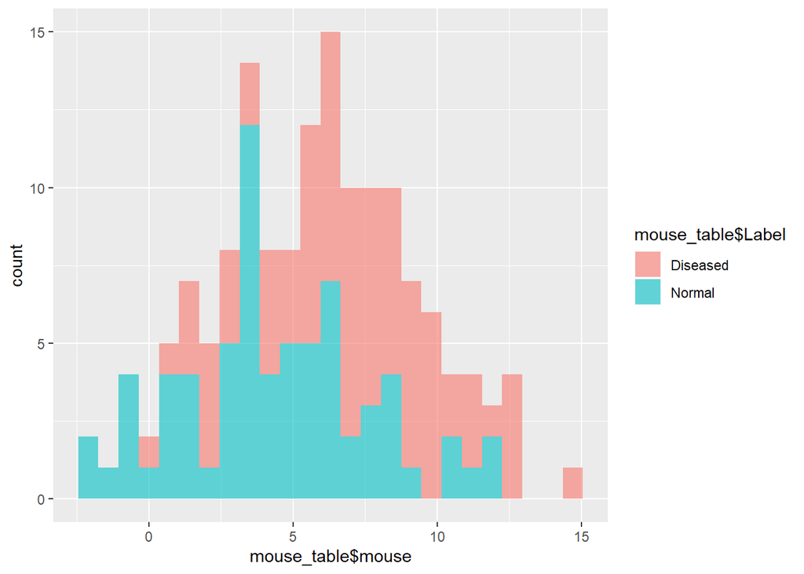

```r
library(easyGgplot2)
load("C:/Users/PoChun/Desktop/Master_NYU/Statistics in Biology/Midterm/midterm_upload_2019/midterm_mice.RData")
mice_diseased <- diseased
mice_normal <- normal
mouse_all<-c(mice_diseased,mice_normal)
Label<-c(rep("Diseased",80),rep("Normal",70))
mouse_table<-cbind(Label,mouse_all)
mouse_table<-data.frame(mouse_table)
mouse_table$mouse<- as.numeric(as.character(mouse_table$mouse))
ggplot(aes(x=mouse_table$mouse, fill=mouse_table$Label), data=mouse_table,) + geom_histogram(alpha=0.6, binwidth = 0.7)
```

Estimate the effect size of interest here.

```r
library(effsize)
mean_diseased<-mean(mice_diseased)
mean_normal<-mean(mice_normal)
sd_diseased<-sd(mice_diseased)
sd_normal<-sd(mice_normal)
pooled_var<- sqrt(((sd_diseased^2)+(sd_normal^2))/2)
effect_size <- (mean_diseased-mean_normal)/pooled_var
print(effect_size)
```

```
## [1] 0.7807385
```

```r
cohen.d(mice_diseased,mice_normal)
```

```
##
## Cohen's d
##
## d estimate: 0.7820183 (medium)
## 95 percent confidence interval:
##     lower     upper
## 0.4465182 1.1175184
```

Compute a p-value to indicate the strength of evidence against the null hypothesis of no difference in location of the distributions of these two samples using: (1) a parametric test; (2) a non-parametric test and (3) a permutation test. Comment on the assumptions, advantages and limitations of each method.

### (1) a parametric test

A: Null hypothesis: The mean of the mice of diseased and normal have no differenece Alternative hypothesis: The mean of the mice of diseased and normal is different

For a parametric test, the assumptions are that the population is normally distributed and the observations are independent. To check the first assumption, use qqplot to see if it is normally distributed. From the graph, we can see that the data is almost a linear line. Therefore, we assume the population is normally distributed.

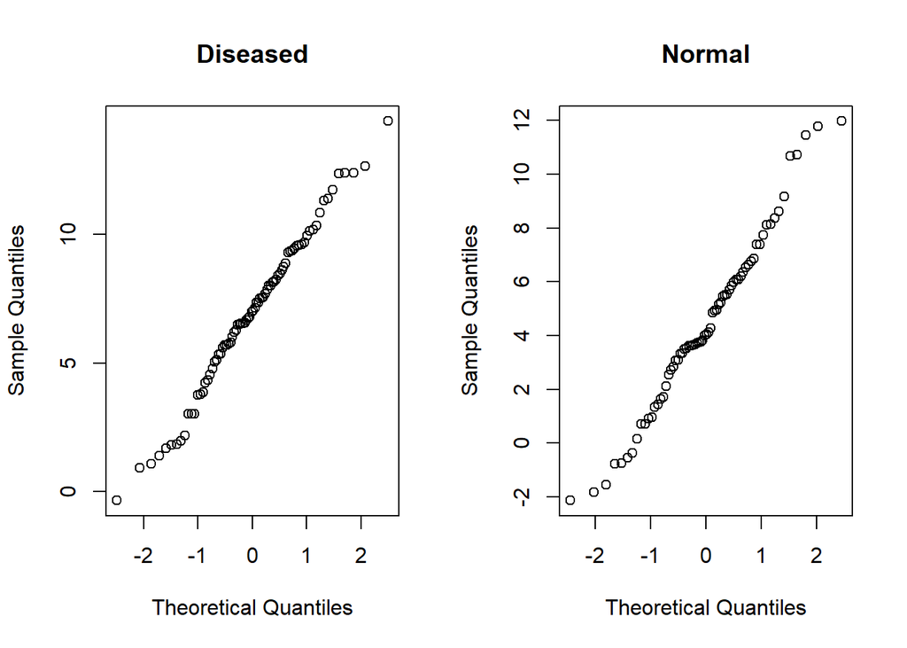

```r
par(mfrow=c(1,2))
qqnorm(mice_diseased, main = "Diseased")
qqnorm(mice_normal, main = "Normal")
```

```r
mean_diseased<-mean(mice_diseased)
mean_normal<-mean(mice_normal)
sd_diseased<-sd(mice_diseased)
sd_normal<-sd(mice_normal)
z_score <-  (mean_diseased-mean_normal)/(sqrt(sd_diseased^2/80+sd_normal^2/70))
p_value <- 2*pt(-abs(z_score), df=148)
print(p_value)
```

```
## [1] 4.511524e-06
```

```r
t.test(mice_diseased,mice_normal)
```

```
##
##  Welch Two Sample t-test
##
## data:  mice_diseased and mice_normal
## t = 4.7627, df = 143.22, p-value = 4.631e-06
## alternative hypothesis: true difference in means is not equal to 0
## 95 percent confidence interval:
##  1.466719 3.547958
## sample estimates:
## mean of x mean of y
##  6.938536  4.431197
```

The p-value strongly suggested to reject the null hypothesis. In parametric test, it is a way to estimate the difference of mean. Advantages: Parametric tests have greater statistical power, if an effect actually exists, a parametric analysis is more likely to detect it. Also, the parametric test can provide trustworthy result althought your data is not normally distributed. Disadvantages: When it comes to the small data sets in which less than 30, it may not predict well. Also, it will be affected by outliers sometimes.

### (2) a non-parametric test

For non-parametric test, the test assumption do not require the data follow the normal distribution which is not the same compared to parametric test.

```r
wilcox.test(mice_diseased,mice_normal,alternative = "two.sided")
```

```
##
##  Wilcoxon rank sum test with continuity correction
##
## data:  mice_diseased and mice_normal
## W = 4018, p-value = 4.508e-06
## alternative hypothesis: true location shift is not equal to 0
```

The p-value strongly suggested to reject the null hypothesis.

Advantages: It is powerful to analyze different data, like ordinal and ranked and not be tripped up by outliers which is not the case in parametric test that can only analyze continuous data. Also, nonparametric tests assess the median which can be better than using mean in parametric test.

Disadvantages: Different nonparametric test has their own way to handle outliers which sometimes makes nonparametric test assumptions harder to meet.

### (3) a permutation test

Permutation test do not need to specify the distribution beforehand which is the same as non-parametric test.

```r
mean_diseased<-mean(mice_diseased)
mean_normal<-mean(mice_normal)
mean_difference<-mean_diseased-mean_normal
combine_mice<-c(mice_diseased,mice_normal)
number<-0
#print(mean_difference)
for (i in 1:10000000) {
  mean_difference2<-0
  combine_mice<- sample(combine_mice,replace = FALSE)

  #print(mean(combine_mice[1:80]))
  #print(mean(combine_mice[81:150]))
  a = mean(combine_mice[1:80])
  b = mean(combine_mice[81:150])
  mean_difference2 <- a-b
  #print(mean_difference2)
  if(mean_difference2 > mean_difference){
        number <- number+1
  }
}
p_value<-number/10000000
print(p_value)
```

```
## [1] 2.3e-06
```

The p-value strongly suggested to reject the null hypothesis.

Advantages: Permutation tests works for any test statistics, regardless of its distribution. They are able to analyze different kind of data same as nonparametric test did, like ordinal or categorical data.

Disadvantages: Permutaion test is computationally intensive as well as the limited complexity of designs they can handle.

Note: You may use the R “.test”" functions. For the parametric test, use a model formula of the experimental design in your solution.

Check the assumptions for the parametric test using appropriate plots, and comment on them.

Note: you can load RData files into R using the load function.

## Problem 4

Size of a growing colony of yeast in log phase (exponental growth) is measured, by a somewhat noisy method, at a number of time points. In this case, the log of colony size should be a linear function of time, and the slope is equal to the exponential growth rate constant. The data are in file Growth.Yeast.txt and can be read into a working session or R by using the read.table() function. The column labels are mostly self-explanatory; time is measured in units of hr.

1. Plot log(colony size) versus time. Use R’s lm function to compute the slope of the regression line $b_1$ and its p-value; i.e., in the model formula $\hat y_i=b_0+b_1\,x$ (where $x$ and $y$ are time, and log.size, respectively).

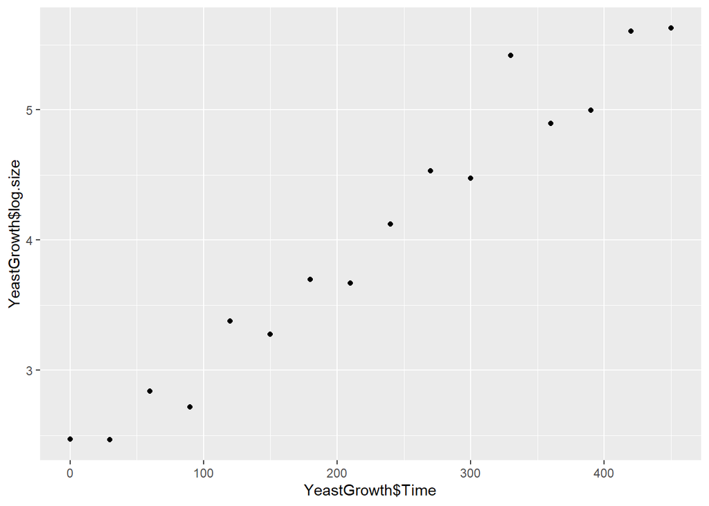

```r
library(ggplot2)
library(data.table)
library(readr)
YeastGrowth <- read_table2("C:/Users/PoChun/Desktop/Master_NYU/Statistics in Biology/Midterm/midterm_upload_2019/YeastGrowth.txt",
    col_names = FALSE, skip = 1)
names(YeastGrowth)[2]<-"Time"
names(YeastGrowth)[3]<-"log.size"
ggplot(YeastGrowth, aes(x = YeastGrowth$Time, y = YeastGrowth$log.size)) +geom_point()
```

```r
model <- lm(YeastGrowth$log.size ~ YeastGrowth$Time, data = YeastGrowth)
model
```

```
##
## Call:
## lm(formula = YeastGrowth$log.size ~ YeastGrowth$Time, data = YeastGrowth)
##
## Coefficients:
##      (Intercept)  YeastGrowth$Time
##         2.304217          0.007587
```

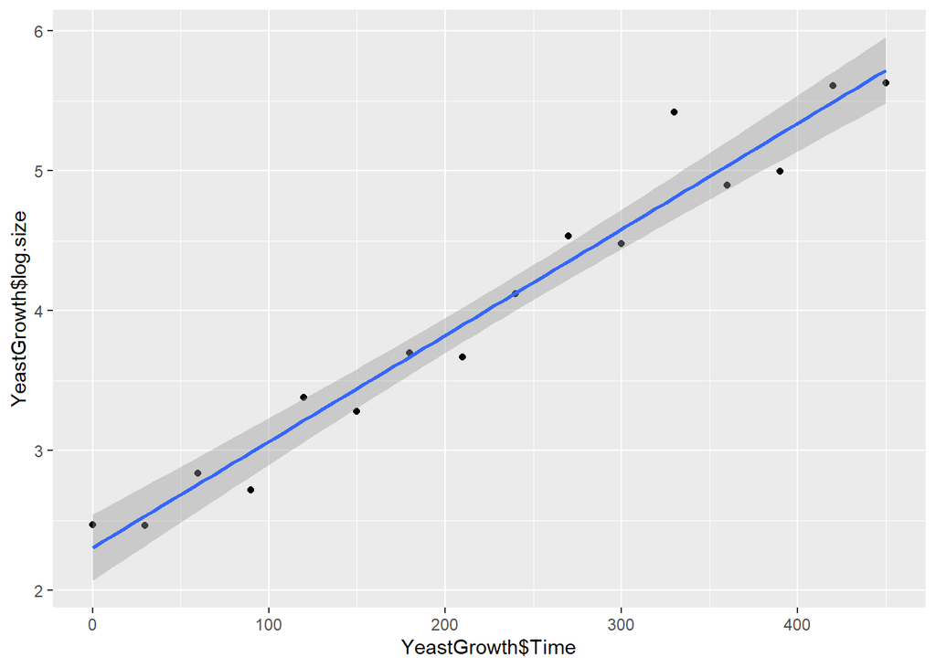

```r
ggplot(YeastGrowth, aes(x = YeastGrowth$Time, y = YeastGrowth$log.size)) +geom_point() +  stat_smooth(method = lm)
```

2. Make a scatter plot of log.size vs. time, and add the regression line using R’s abline function.

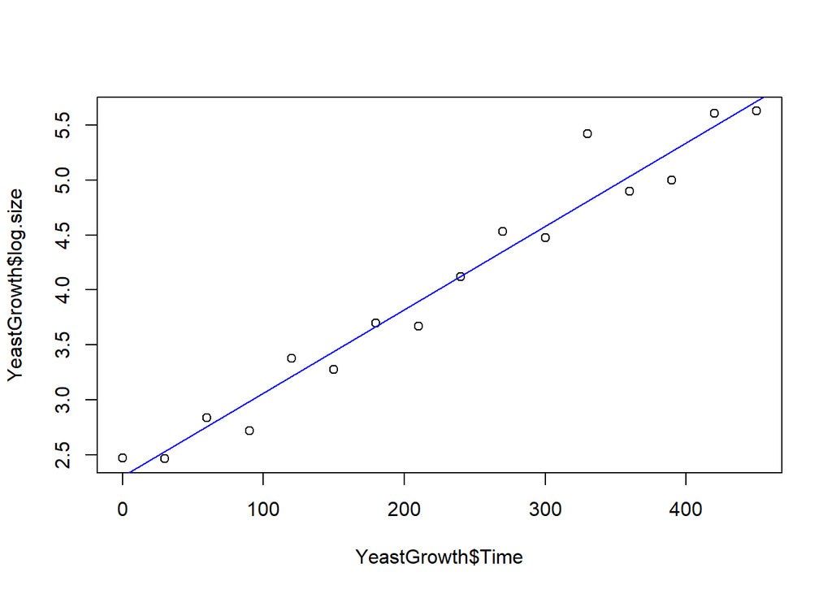

```r
plot(YeastGrowth$Time,YeastGrowth$log.size)
abline(lm(YeastGrowth$log.size ~ YeastGrowth$Time, data = YeastGrowth), col = "blue")
```

3. Compute a 95% confidence interval for the population slope $\beta_1$, and explain your method. (Some of the information you need is provided by applying the summary.lm() function to the ouput of the lm() function.) Check your result by using the function confint() on the ouput of the lm() function.

c(“lower” = coefficients - qt(0.975, df = 14) * Standard error, “upper” = coefficients + qt(0.975, df = 14) * Standard error)

```r
c("lower" = 0.007587 - qt(0.975, df = 14) * 0.0004168,
  "upper" = 0.007587 + qt(0.975, df = 14) * 0.0004168)
```

```
##       lower       upper
## 0.006693053 0.008480947
```

```r
Yeast.lm = lm(YeastGrowth$log.size ~ YeastGrowth$Time)
#Then we create a new data frame that set the waiting time value.
#predict(Yeast.lm2,interval="confidence")
summary.lm(Yeast.lm)
```

```
##
## Call:
## lm(formula = YeastGrowth$log.size ~ YeastGrowth$Time)
##
## Residuals:
##      Min       1Q   Median       3Q      Max
## -0.26795 -0.14647 -0.03547  0.12636  0.61069
##
## Coefficients:
##                   Estimate Std. Error t value Pr(>|t|)
## (Intercept)      2.3042167  0.1100688   20.93 5.79e-12 ***
## YeastGrowth$Time 0.0075871  0.0004168   18.20 3.83e-11 ***
## ---
## Signif. codes:  0 '***' 0.001 '**' 0.01 '*' 0.05 '.' 0.1 ' ' 1
##
## Residual standard error: 0.2305 on 14 degrees of freedom
## Multiple R-squared:  0.9595, Adjusted R-squared:  0.9566
## F-statistic: 331.4 on 1 and 14 DF,  p-value: 3.833e-11
```

```r
confint(Yeast.lm)
```

```
##                        2.5 %      97.5 %
## (Intercept)      2.068142568 2.540290891
## YeastGrowth$Time 0.006693206 0.008480954
```

```r
#confint(Yeast.lm2)
```

## Problem 5

An experiment performed on flies examined the effect of two stressors on the lengths of their eye stalks. The data is in the file “midterm_fly.RData” (in variables fly_stressor1 and fly_stressor2). One group was exposed to stressor1, and an independent group was exposed to stressor2.

A: Null hypothesis: The lengths of their eye stalks has no difference Alternative hypothesis: The lengths of their eye stalks is different

Estimate the size of the effect of interest here.

```r
load("C:/Users/PoChun/Desktop/Master_NYU/Statistics in Biology/Midterm/midterm_upload_2019/midterm_fly.RData")
fly_1<-fly_stressor1
fly_2<-fly_stressor2

fly_1_mean<-mean(fly_1)
fly_2_mean<-mean(fly_2)

fly_1_sd<-sd(fly_1)
fly_2_sd<-sd(fly_2)

pooled_var<- sqrt(((fly_1_sd^2)+(fly_2_sd^2))/2)
effect_size <- (fly_1_mean-fly_2_mean)/pooled_var
print(effect_size)
```

```
## [1] 2.420807
```

```r
cohen.d(fly_1,fly_2)
```

```
##
## Cohen's d
##
## d estimate: 2.350418 (large)
## 95 percent confidence interval:
##    lower    upper
## 1.567617 3.133218
```

Perform and report on the results of an appropriate statistical test for comparing the mean eye stalk length in the two groups. Include diagnostic plots to check your assumptions and justify your choice of test. (You may use any R function in your solution.)

A: If we want to use the t-test, we need to make sure the data is normally distributed. Therefore, we use two ways to verify. One is by qqplot and the other is by sharpiro test. For the first one, the plot should look like a straight line in the case of normal distributed. As for the second test, the number indicate that we can not reject the null hypothesis(which is data is normally distributed in this case)

```r
t.test(fly_1, fly_2, paired = F)
```

```
##
##  Welch Two Sample t-test
##
## data:  fly_1 and fly_2
## t = 8.3477, df = 26.568, p-value = 6.666e-09
## alternative hypothesis: true difference in means is not equal to 0
## 95 percent confidence interval:
##  0.3801943 0.6282581
## sample estimates:
## mean of x mean of y
##  2.047143  1.542917
```

```r
print("p-value by formula")
```

```
## [1] "p-value by formula"
```

```r
t_score<-(fly_1_mean-fly_2_mean)/(sqrt(fly_1_sd^2/21+fly_2_sd^2/24))
p_value2 <- 2*pt(-abs(t_score),df = 43)
print(p_value2)
```

```
## [1] 1.534138e-10
```

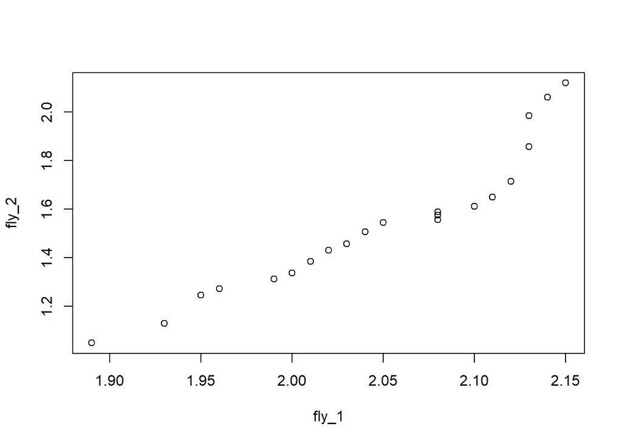

```r
qqplot(fly_1,fly_2)
```

```r
shapiro.test(fly_1)
```

```
##
##  Shapiro-Wilk normality test
##
## data:  fly_1
## W = 0.95274, p-value = 0.3834
```

```r
shapiro.test(x = fly_2)
```

```
##
##  Shapiro-Wilk normality test
##
## data:  fly_2
## W = 0.96125, p-value = 0.464
```

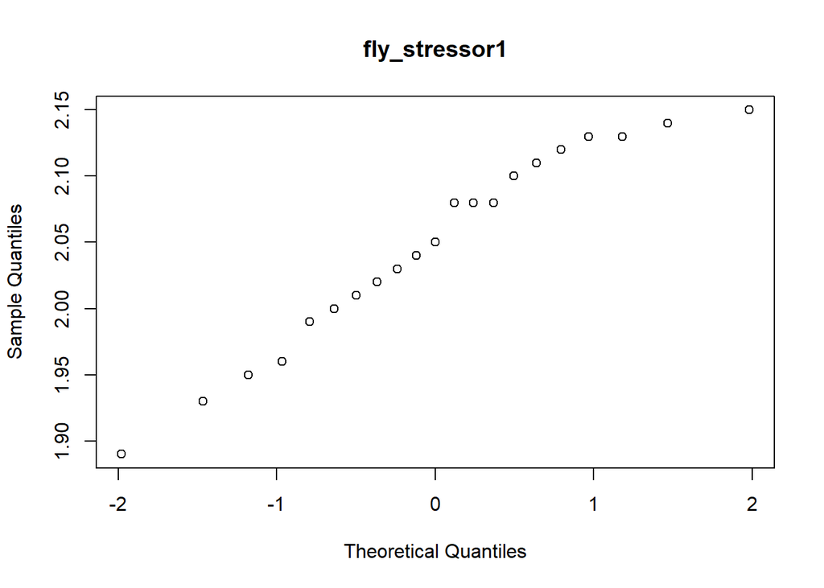

```r
qqnorm(fly_1, main="fly_stressor1")
```

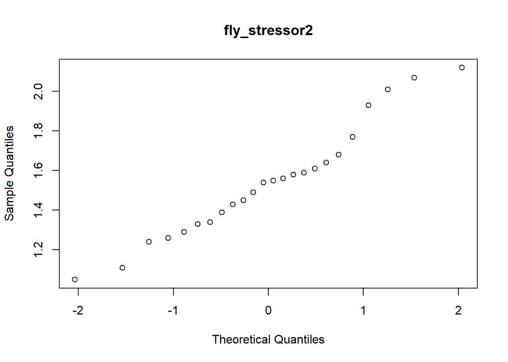

```r
qqnorm(fly_2, main="fly_stressor2")
```

## Problem 6

Read Nuzzo, R., Statistical Errors, Nature, Vol 506, 2014 and answer the following questions:

If you were asked ``what is a p-value?", give your response, giving both the definition in conditional probability notation as well as a prose description (answer must be less than 150 words).

A: P-value was first introduced by Ronald Fisher in the early 1920s. The idea was to run an experiment, then see if the results were consistent with what random chance might produce. In other words, supposed we have a null hypothesis to test. The small p-value (<0.05) tells you that you are very likely to reject the null hypothesis. However, it is not guaranteed you will get the same result because the odds that a real effect was there in the first place is not known.

In terms of the definition in conditional probability, the p-value can be described as $Pr \left(value\ this (or\ more) extreme | null\ hypothesis\right)$ which means given that null hypothesis is true. what is the probability of obtaining a result at least as extreme as the one that was actually observed?

How would you interpret a p-value of 0.01 in terms of its strength of evidence against the null hypothesis: what rate of false positive results might you expect if an independent lab attempted to replicated an experiment with a p-value of 0.01, and what does that depend on?

A P value of 0.01 would be thought as highly statistically significant. However, a P value of 0.01 corresponds to a false-alarm probability of at least 11%. It depends on the odds that a real effect was there in the first place.

List and briefly discuss three caveats for using p-values discussed in Nuzzo.

1. Significance is no indicator of prectical relevance. How much of an effect is there? (Nuzzo) For example, the experiment can have a really low p-value but the overall difference is only 1%.
2. The idea of P-hacking which means people try to get low p-value by all means. For example, the finding seems to have been obtained through p-hacking, the authors dropped one of the conditions so that the overall p-value would be less than 0.05 (Nuzzo)
3. A p-value can not answer the question. What are the odds that a hypothesis is correct?